# Sortino Shiny Write up

Welcome to part three in our series on the Sortino Ratio. By way of quick review, the [first post](https://www.datascience.com/blog/calculate-the-sortino-ratio) focused on calculating the Sortino Ratio and the [second post](https://www.datascience.com/blog/visualize-sortino-ratio) focused on visualizing the Sortino Ratio. Today, we will combine that previous work into a Shiny application that allows an end user to build a custom portfolio and visualize the Sortino Ratio interactively (if you’re new to Shiny, there’s lots of information, tutorials and examples at the Shiny homepage here). We are going to lean heavily on the previous work and I recommend at least skimming through the previous posts before diving in here. Not only will it provide background on the substance and functions but it should also provide the motivation for the Shiny app. After spending a lot of time on the calculating and visualizing, Shiny allows us to share our work with a broader audience beyond other R coders.

Let’s get to our Sortino Ratio Shiny app, the final version of which is available [here](http://www.reproduciblefinance.com/shiny/sortino-ratio/). And here is what the app looke like before a user clicks:

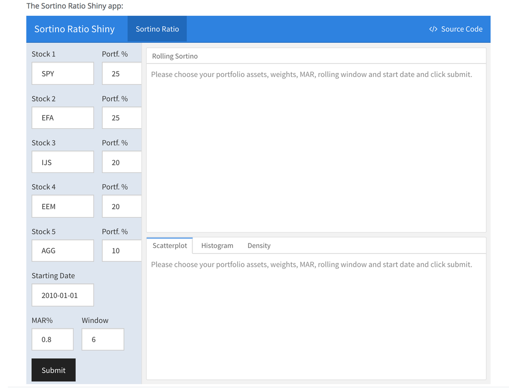

The full source code can be accessed via the aptly labeled ‘source code’ button at the top right of the app. Close readers will see that it was built in an Rmarkdown file (with output: flexdashboard::flexdashboard and runtime: shiny added to the YAML header).

```r
---
title: "Sortino Ratio Shiny"
runtime: shiny
output:
  flexdashboard::flex_dashboard:
    orientation: rows
    source_code: embed
---
```

This app could have been built using the classical app.r file format, but I prefer to use a flexdashboard because it keeps the entire workflow in the Rmarkdown world. In the previous posts, we used Rmarkdown and code chunks to enforce logic on our data import, calculations and visualizations. This Shiny app follows the same code chunk structure and I find that the logic and functions translate well.

We will review the substantive code in detail but we won’t cover formatting features like how to create a new row or how to tab-set a row. The ‘source code’ button shows all the formatting code for the curious.

On to the substance where our first task is to build an input sidebar and enable users to choose five stocks and weights. We will use `textInput("stock1",...))` to create a space where the user can type a stock symbol and we will use `numericInput("w1",...)` to create a space where the user can enter a numeric weight. Since we have 5 stocks and weights, we repeat this 5 times. Notice that the stock symbol field uses `textInput()` because the user needs to enter text and the weight field uses `numericInput()` because the user needs to enter a number.

```r
library(tidyverse)
library(highcharter)
library(tidyquant)
library(timetk)

fluidRow(
  column(7,
  textInput("stock1", "Stock 1", "SPY")),
  column(5,
  numericInput("w1", "Portf. %", 25, min = 1, max = 100))
)

fluidRow(
  column(7,
  textInput("stock2", "Stock 2", "EFA")),
  column(5,
  numericInput("w2", "Portf. %", 25, min = 1, max = 100))
)

fluidRow(
  column(7,
  textInput("stock3", "Stock 3", "IJS")),
  column(5,
  numericInput("w3", "Portf. %", 20, min = 1, max = 100))
)

fluidRow(
  column(7,
  textInput("stock4", "Stock 4", "EEM")),
  column(5,
  numericInput("w4", "Portf. %", 20, min = 1, max = 100))
)

fluidRow(
  column(7,
  textInput("stock5", "Stock 5", "AGG")),
  column(5,
  numericInput("w5", "Portf. %", 10, min = 1, max = 100))
)
```

Next, we give the end user the ability to choose a start date with `dateInput("date",...)`.

```r
fluidRow(
  column(7,
  dateInput("date", "Starting Date", "2010-01-01", format = "yyyy-mm-dd"))
)
```

And for the final inputs, let’s have a row where the user can choose a MAR and the length of the rolling window. These are both numbers so we use `numericInput("mar",...)` and `numericInput("window",...)`.

```r
fluidRow(
  column(5,
  numericInput("mar", "MAR%", .8, min = 0, max = 3, step = .01)),
  column(5,
  numericInput("window", "Window", 6, min = 2, max = 24, step = 2))
)
```

Finally, we include a `submit` button for our end user. This button is what takes all those inputs and passes them on to our reactive functions so the Shiny engine can start doing its work. The app won’t fire until the user clicks submit.

```r
actionButton("go", "Submit")
```

After our user clicks ‘submit’, the app will look like this:

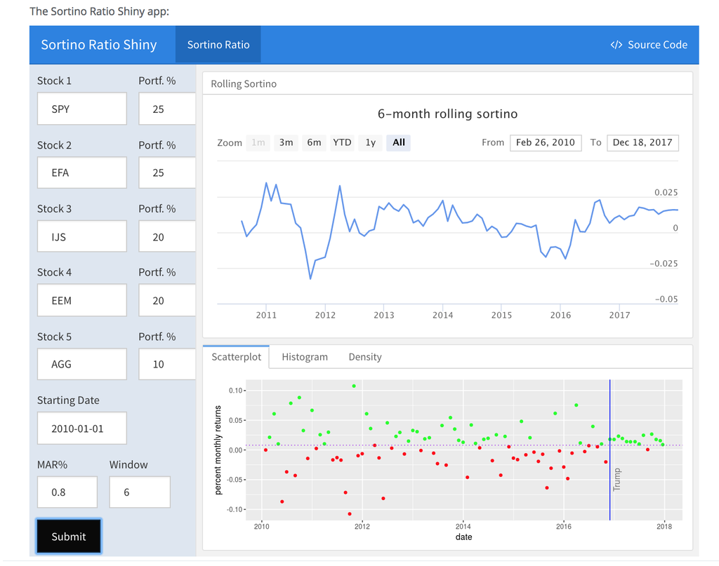

This is a hugely important button because it enables the use of `eventReactives()` to control our computation. Let’s have a look at that first `eventReaactive()` wherein we take the user-chosen stocks and grab their daily prices.

```r
prices <- eventReactive(input$go, {

  symbols <- c(input$stock1, input$stock2, input$stock3, input$stock4, input$stock5)

  getSymbols(symbols, src = 'yahoo', from = input$date,
             auto.assign = TRUE, warnings = FALSE) %>%
  map(~Ad(get(.))) %>%
  reduce(merge) %>%
  `colnames<-`(symbols)
})
```

The first line is tied back to our `submit()` button. The function starts with `prices <- eventReactive(input$go, {...` which means the function won’t start firing until the submit button is clicked. The clicking of submit is the event that starts the reactivity. That’s important because we don’t want the reactive function to start firing whenever a user changes any of the inputs in our sidebar. If this were a normal reactive, it would read `prices <- reactive({...` and it would start firing anytime one of our inputs changed. That would frustrate the end user!